# Lab 5

### Enter the names of the group members here: Emaan Haq, Andy Park, Armaan Christ

**This assignment is due by the end of the day. Only one student in the group submits a pdf file on Gradescope.**

*For all questions, include the R commands/functions that you used to find your answer (show R chunk). Answers without supporting code will not receive credit. Write full sentences to describe your findings.*

The data for this lab simulate data from a health care network in a single U.S. state for a single year. There are three CSV files in the dataset:

- `people.csv` - this file contains demographic information on each individual person in the dataset, including their age, gender, race, and county of residence. People are identified by a random string in the `id` column.
- `healthcare.csv` - this file contains hospitalization information for each person that went to the hospital that year. The only people who are in this file are people who had a hospitalization. It is possible for people to appear multiple times in this file if they had multiple hospitalizations. The IDs in the `id` column here correspond to the IDs in the `people.csv` file.
- `exposure.csv` - this file contains county-wide averages of air pollution for each of the counties in the state. Counties are identified by a number in the `county` column.

### Question 1 (2 pts)

For this lab we will be using

```r
library(tidyverse)

## Read in the 'people.csv' dataset
people <- read_csv("people.csv")
```

Write code to read in the ‘exposure.csv’ and save it to an object called `exposure`

```r
## Read in the 'exposure.csv' dataset
exposure <- read_csv("exposure.csv")
```

Write code to read in the ‘healthcare.csv’ and save it to an object called `healthcare`

```r
## Read in the 'healthcare.csv' dataset
healthcare <- read_csv("healthcare.csv")
```

Which `id` value had the most number of hospitalizations (regardless of diagnosis) as recorded in the `healthcare` table? How many hospitalizations did this person have?

```r
## Count the number of hospitalizations per person
most_hospitalizations <- healthcare %>%
  count(id, name = "hospitalization_count") %>%
  arrange(desc(hospitalization_count)) %>%
  slice(1)

most_hospitalizations
```

```
## # A tibble: 1 × 2
##   id       hospitalization_count
##   <chr>                    <int>
## 1 5d6faee3                   118
```

**ID 5d6faee3 had the highest number of hospitalizations, totaling 118 visits. This indicates frequent healthcare usage by this individual.**

### Question 2 (2 pts)

Use the `inner_join()` function to answer the following question: How many hospitalizations did Males have in this dataset (for any diagnosis)?

```r
## Count hospitalizations for males
maleforhospitalizations <- healthcare %>%
  inner_join(people, by = "id") %>%
  filter(gender == "M") %>%
  nrow()

maleforhospitalizations
```

```
## [1] 9410
```

**Males accounted for a total of 9,410 hospitalizations in this dataset. This suggests that males may have a higher healthcare utilization rate compared to other groups.**

### Question 3 (2 pts)

How many hospitalizations did people less than the age of 10 have in this dataset (for any diagnosis)?

```r
## Count total hospitalizations for people under the age of 10
totalhospitalizationsless10 <- healthcare %>%
  inner_join(people, by = "id") %>%
  filter(age < 10) %>%
  nrow()
totalhospitalizationsless10
```

```
## [1] 10405
```

**Children under the age of 10 had a total of 10,405 hospitalizations. This highlights a high frequency of hospital visits among young children, possibly due to common childhood illnesses or preventive care.**

### Question 4 (2 pts)

What is the average level of pollution exposure for people aged less than 6 in this dataset?

```r
## Get average pollution exposure for people under 6
avgexposureless6 <- people %>%
  filter(age < 6) %>%
  inner_join(exposure, by = "county") %>%
  summarize(mean(pollution, na.rm = TRUE)) %>%
  pull()

avgexposureless6
```

```
## [1] 9.504026
```

**The average pollution exposure level for children under 6 years old is 9.504. This suggests that young children in this dataset are exposed to moderate pollution levels, which could have health implications.**

### Question 5 (2 pts)

Using the `healthcare` object, group the rows by the `id` variable, count the total number of hospitalizations for each ID, and store this data frame in a new object called `grouphealth`. The first 10 rows of the `grouphealth` data frame should look something like the following, where there is a single row for each ID and the `n` column indicates the number of hospitalizations:

```r
> grouphealth
# A tibble: 3,545 × 2
   id           n
   <chr>    <int>
 1 001ab789     2
 2 001c251d     2
 3 0026eb32     8
 4 00319741     1
 5 0031c41c     4
 6 0034b1ad     1
 7 0040ceab     4
 8 00484af8     9
 9 004fa59a     1
10 0053fd8b     6
```

Which ID has the 5th highest number of hospitalizations?

```r
## Create grouphealth and find the 5th highest hospitalization ID
fifth_highestid <- healthcare %>%
  count(id, name = "n") %>%
  arrange(desc(n)) %>%
  slice(5) %>%
  pull(id)

fifth_highestid
```

```
## [1] "8a76dd92"
```

**ID 8a76dd92 has the 5th highest number of hospitalizations.**

### Question 6 (2 pts)

Left join the `people` data frame with the `grouphealth` data frame to create a new data frame called `peoplehealth`. The first 10 rows of the `peoplehealth` data frame should look as follows:

```r
> peoplehealth
# A tibble: 29,443 × 6
   id         age gender race     county     n
   <chr>    <dbl> <chr>  <chr>     <dbl> <int>
 1 da842d0b    25 M      white        18    NA
 2 94e7be91     8 F      hispanic     15    NA
 3 ba3e3360    18 F      black        15    NA
 4 25339012    87 M      black        19    NA
 5 d2e3dc89    64 F      black         9    NA
 6 b66e388b     8 F      hispanic      5    NA
 7 494435b4     9 M      white         7    NA
 8 061e2436    22 M      black        16    NA
 9 52bdf8c3     3 M      white         2     2
10 d7bce11f    83 M      hispanic     16    NA
```

In the `peoplehealth` data frame, how many people have an `NA` value for the `n` column?

```r
## Create grouphealth first and peoplehealth using left_join and sorting number of NAs.
grouphealth <- healthcare %>%
  count(id, name = "n")

peoplehealth <- people %>%
  left_join(grouphealth, by = "id")

nacount <- peoplehealth %>%
  filter(is.na(n)) %>%
  nrow()

nacount
```

```
## [1] 25898
```

**There are 25,898 people who have an `NA` value for the `n` column.**

### Question 7 (2 pts)

The `NA` values in the `n` column of the `peoplehealth` data frame represent people who never went to the hospital. The `NA` values were created when we merged the `people` and `grouphealth` data frames together. We can replace these `NA` values with 0s using a combination of `mutate()` and the `replace_na()` function. (Look at `?replace_na for more details.)

Replace the `NA` values in `peoplehealth`with zeros and then merge this new data frame (containing the replaced `NA` values) with the `exposure` data frame. Save the resulting merged data frame to an object named `alldata`.

```r
## Replace NA values with 0 in n. Merge with exposure data frame.

peoplehealth <- peoplehealth %>%
  mutate(n = replace(n, is.na(n), 0))

alldata <- peoplehealth %>%
  inner_join(exposure, by = "county")

head(alldata)
```

```
## # A tibble: 6 × 7
##   id         age gender race     county     n pollution
##   <chr>    <dbl> <chr>  <chr>     <dbl> <dbl>     <dbl>
## 1 da842d0b    25 M      white        18     0      8.66
## 2 94e7be91     8 F      hispanic     15     0      9.35
## 3 ba3e3360    18 F      black        15     0      9.35
## 4 25339012    87 M      black        19     0      8.71
## 5 d2e3dc89    64 F      black         9     0      8.81
## 6 b66e388b     8 F      hispanic      5     0      8.85
```

Make a scatterplot of pollution (`pollution`) and number of hospitalizations (`n`). Make sure to put appropriate x-axis and y-axis labels.

How would you characterize the relationship between these two variables in this scatterplot?

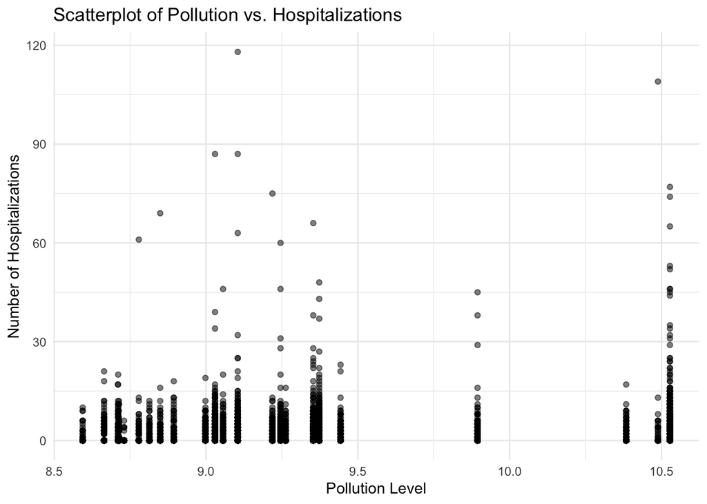

```r
## Scatterplot of pollution vs. number of hospitalizations
ggplot(alldata, aes(x = pollution, y = n)) +
  geom_point(alpha = 0.5) +
  labs(
    x = "Pollution Level",
    y = "Number of Hospitalizations",
    title = "Scatterplot of Pollution vs. Hospitalizations"
  ) +
  theme_minimal()
```

**The scatterplot shows no clear relationship between pollution levels and the number of hospitalizations. However, the high density of overlapping points makes it challenging to draw definitive conclusions. Further analysis, such as calculating correlation coefficients, may provide more insight.**

### Question 8 (2 pts)

Use the `alldata` object to compute the average hospitalizations for each county and the average pollution for each county. Using these county averages, make a scatterplot between the county average hospitalizations (y-axis) and the county average pollution (x-axis). Make sure to put appropriate x-axis and y-axis labels.

How would you characterize the relationship between pollution and hospitalizations in this plot?

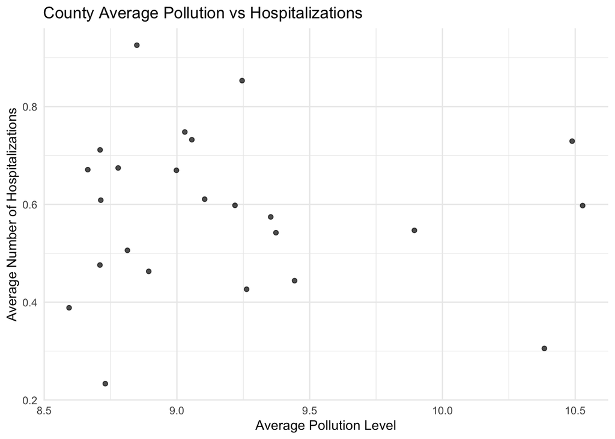

```r
## Calculate county averages for hospitalizations and pollution and generate scatterplot of county average pollution vs. average hospitalizations

countyavg <- alldata %>%
  group_by(county) %>%
  summarize(avg_hospital = mean(n),
            avg_poll = mean(pollution))

ggplot(countyavg, aes(x = avg_poll, y = avg_hospital)) +
  geom_point(alpha = 0.7) +
  labs(
    x = "Average Pollution Level",
    y = "Average Number of Hospitalizations",
    title = "County Average Pollution vs Hospitalizations"
  ) +
  theme_minimal()
```

**The scatterplot shows no strong correlation between average pollution levels and average hospitalizations by county. This suggests that other factors may influence hospitalization rates more significantly than pollution exposure alone.**

### Question 9 (2 pts)

How many people (IDs) never had any hospitalizations? In other words, how many IDs in the `people` table do NOT appear in the `healthcare` table?

NOTE: It is possible to answer this question without a join function but try using one of the join functions to do so (you will get credit either way).

```r
## Count IDs in people not present in healthcare using left_join and checking NA
nohospital <- people %>%
  left_join(healthcare, by = "id") %>%
  filter(is.na(diagnosis)) %>%
  nrow()

nohospital
```

```
## [1] 25898
```

**There are 25,898 people who never had any hospitalizations.**

### Formatting: (2 pts)

Comment your code, write full sentences, and knit your file!